# Trabalho prático de ICD

# Limpeza dos dados / Análise exploratória

dataframe hot

```python
#retirei a coluna url
hot = hot[[
    'WeekID',
    'Week Position',
    'Song',
    'Performer',
    'SongID',
    'Instance',
    'Previous Week Position',
    'Peak Position',
    'Weeks on Chart',
]]

#adicionando coluna do ano em que a musica ficou no hot100
hot['Ano']= hot['WeekID'].str.slice(-4)
```

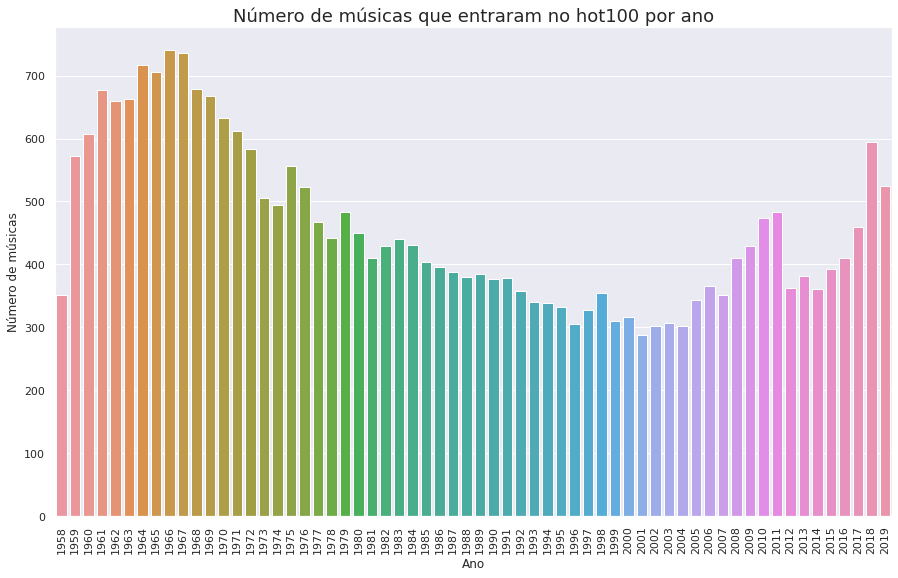

```python
#quantidade de musicas que entraram na hot 100 por ano
songs_per_year = (hot.loc[(hot['Instance'] == 1)].groupby('SongID')
                 .agg({'Ano': 'min'})
                 .reset_index()
                 .groupby('Ano')
                 .agg({'SongID': 'count'})
                 .reset_index()
                 .rename(columns={'SongID':'n_songs'}))

sns.set()

# Tamanho default das figuras
plt.rcParams['figure.figsize'] = (15.0, 9.0)

sns.barplot(
    songs_per_year['Ano'],
    songs_per_year['n_songs'],
)

# Título do plot
plt.title("Número de músicas que entraram no hot100 por ano", fontsize=18)
# Nome do eixo x
plt.xlabel('Ano')
# Nome do eixo y
plt.ylabel('Número de músicas')
plt.xticks(rotation=90)
plt.show()
```

dataframe features (adicao das colunas, ano, weeks on top1, weeks on chart, chart debut)

```python
#adicionando coluna 'anos' no df de features
features['ano'] = features.SongID.map(hot.set_index('SongID')['Ano'].to_dict())

#adicionando coluna 'weeks on top1' de quantidade de semanas em primeiro no df de features
top1 = hot.loc[(hot['Week Position'] == 1)].groupby('SongID').count()
features['weeks on top1'] = features.SongID.map(top1['Week Position'].to_dict())

#adicionando coluna 'weeks on chart' de quantidade de semanas que mais permaneceram no chart no df de features
weeksOnChart = hot.groupby('SongID').max()
features['weeks on chart'] = features.SongID.map(weeksOnChart['Weeks on Chart'].to_dict())

#adicionando coluna 'chart debut' de posicao de estreia no chart no df de features
chartDebut = hot.loc[(hot['Previous Week Position'].isnull())].groupby('SongID').min()
features['chart debut'] = features.SongID.map(chartDebut['Week Position'].to_dict())
```

```python
# Drop unnecessary columns
features = features[[
    'SongID',
    'Performer',
    'Song',
    'ano',
    'chart debut',
    'weeks on chart',
    'weeks on top1',
    'spotify_genre',
    'spotify_track_explicit',
    'spotify_track_duration_ms',
    'spotify_track_popularity',
    'danceability',
    'energy',
    'key',
    'loudness',
    'mode',
    'speechiness',
    'acousticness',
    'instrumentalness',
    'liveness',
    'valence',
    'tempo',
    'time_signature'
]]
```

# 3. Como foi a evolução das características das músicas mais ouvidas ao longo dos anos?

```python
#media das caracteristicas das musicas em cada ano
featuresMediaPorAno = features.groupby('ano').mean().reset_index()
featuresMediaPorAno708090 = featuresMediaPorAno[featuresMediaPorAno['ano']
                                                .isin(['1958','1965','1970','1975','1980','1985','1990','1995','2000','2005','2010','2015','2019'])]
```

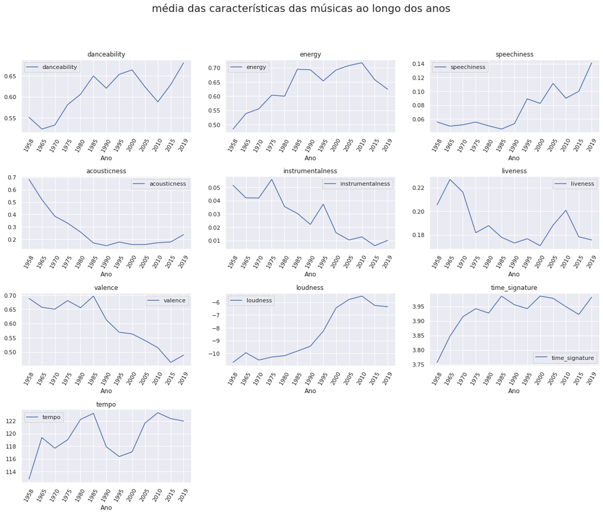

```python
fig = plt.figure(figsize=(20, 15))
fig.subplots_adjust(hspace=0.6, wspace=0.2)
fig.suptitle('média das características das músicas ao longo dos anos', fontsize=20)

caracteristicas = ['danceability', 'energy', 'speechiness', 'acousticness',
            'instrumentalness','liveness', 'valence','loudness','time_signature','tempo']


for index, feature in enumerate(caracteristicas):
    ax = fig.add_subplot(4,3,index+1)

    # Define o plot
    sns.lineplot(x='ano', y=feature,# marker='o',
                         data=featuresMediaPorAno708090, label=feature, sort=False)
#     sns.barplot(x='ano', y=feature,
#                          data=featuresMediaPorAno, label=feature)

    # Título do plot
    plt.title(feature)
    # Nome do eixo x
    plt.xlabel('Ano')
    # Nome do eixo y
    plt.ylabel('')
    # Rotaciona nomes no eixo x
    plt.xticks(rotation=60)
    plt.legend()
plt.show()
```

[figure not shown]

```python
#numero de musicas com conteudo explicito por ano
featuresExplicitPorAno = pd.DataFrame(features.groupby('ano').count().reset_index())

sns.barplot(
    featuresExplicitPorAno['ano'],
    featuresExplicitPorAno['spotify_track_explicit'],
)

# Título do plot
plt.title("Número de músicas com conteúdo explícito", fontsize=18)
# Nome do eixo x
plt.xlabel('Ano')
# Nome do eixo y
plt.ylabel('Número de músicas')
plt.xticks(rotation=90)
plt.show()
```

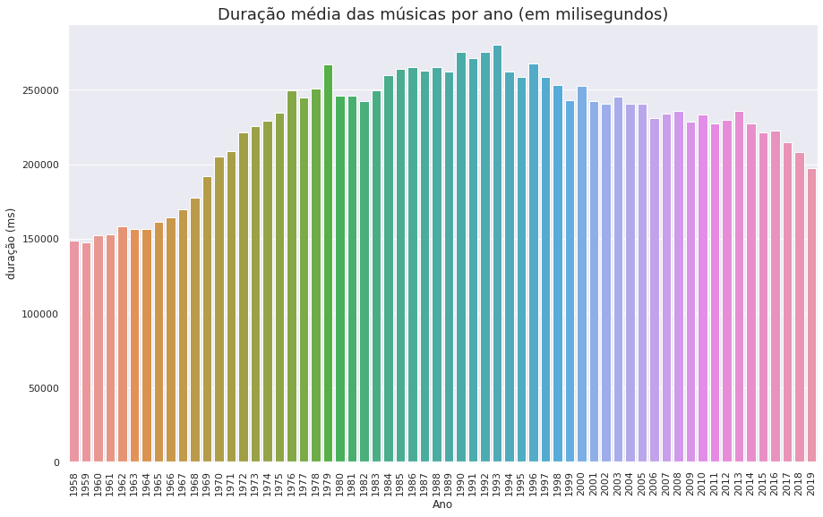

```python
#duracao media das musicas (em milisegundos)

sns.barplot(
    featuresMediaPorAno['ano'],
    featuresMediaPorAno['spotify_track_duration_ms'],
)

# Título do plot
plt.title("Duração média das músicas por ano (em milisegundos)", fontsize=18)
# Nome do eixo x
plt.xlabel('Ano')
# Nome do eixo y
plt.ylabel('duração (ms)')
plt.xticks(rotation=90)
plt.show()
```

# Teste de hipótese

TESTE - Como foi a evolução das características das músicas mais ouvidas ao longo dos anos?

Hipotese nula: a caracterista x das músicas ao longo dos anos é igual/a caracterista x não se alterou ao longo dos anos.

Vamos comparar a danceability de dois anos: 2010 e 2019. Inicialmente, vamos explorar os dados

```python
features_2010_2019 = features[features['ano'].isin(['2010', '2019'])]
```

Vamos pegar o danceability médio de cada ano. temos uma diferença de 0.09. Tal estatística será a nossa $t_{obs}$.

```python
#danceability médio de 2019
filtro2019 = features['ano'] == '2019'
danceability_mean_2019 = features[filtro2019]['danceability'].mean()
danceability_mean_2019
```

```
0.6811282051282043
```

```python
#danceability médio de 2010
filtro2010 = features['ano'] == '2010'
danceability_mean_2010 = features[filtro2010]['danceability'].mean()
danceability_mean_2010
```

```
0.5880625000000004
```

```python
t_obs = danceability_mean_2019 - danceability_mean_2010
t_obs
```

```
0.09306570512820389
```

Teste de permutação

```python
np.random.shuffle(filtro2019.values)
np.random.shuffle(filtro2019.values)
diff = features[filtro2010]['danceability'].mean() - features[filtro2019]['danceability'].mean()
diff
```

```
-0.0006992449664425804
```

```python
N = 10000
diferencas = np.zeros(N)
for i in range(N):
    np.random.shuffle(filtro2019.values)
    np.random.shuffle(filtro2019.values)
    diff = features[filtro2010]['danceability'].mean() - features[filtro2019]['danceability'].mean()
    diferencas[i] = diff
```

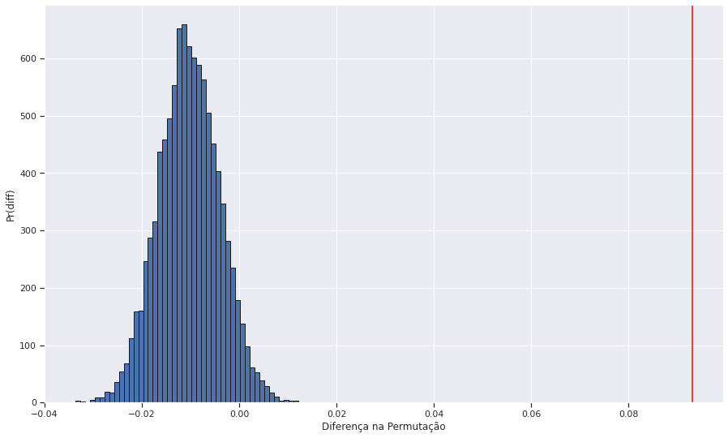

```python
def despine(ax=None):
    if ax is None:
        ax = plt.gca()
    # Hide the right and top spines
    ax.spines['right'].set_visible(False)
    ax.spines['top'].set_visible(False)

    # Only show ticks on the left and bottom spines
    ax.yaxis.set_ticks_position('left')
    ax.xaxis.set_ticks_position('bottom')

plt.hist(diferencas, bins=50, edgecolor='k')
plt.xlabel('Diferença na Permutação')
plt.ylabel('Pr(diff)')
plt.axvline(t_obs, color='red', label='redline')
# plt.text(t_obs+1, 0.10, '$16\%$ dos casos')
despine()
plt.show()
```

O traço vermelho mostra o valor que observamos, as barras mostram as diferentes amostras. t_obs é bastante raro, logo rejeitamos a hipótese nula e indicamos que a variação dos valores de danceability não pode ser explicado pelo acaso.

# IC - Intervalo de Confiança

Alguma característica da música pode influenciá-la a ficar em #1?

Vamos comparar as caracteristicas das músicas que ficaram no top10 com as que chegaram apenas ate a 90 posicao. Para isso fizemos um tratamento dos dados, adicionando uma coluna da melhor posicao de cada musica

```python
best_position = hot.groupby('SongID').min()
features['melhor posicao'] = features.SongID.map(best_position['Peak Position'].to_dict())
```

```python
#vamos olhar os dados gerais
features.describe()
```

|  | chart debut | weeks on chart | weeks on top1 | spotify_track_explicit | spotify_track_duration_ms | spotify_track_popularity | danceability | energy | key | loudness | mode | speechiness | acousticness | instrumentalness | liveness | valence | tempo | time_signature | melhor posicao |
| --- | --- | --- | --- | --- | --- | --- | --- | --- | --- | --- | --- | --- | --- | --- | --- | --- | --- | --- | --- |
| count | 28481.000000 | 28489.000000 | 1080.000000 | 23743.00000 | 2.374300e+04 | 23743.000000 | 23680.000000 | 23680.000000 | 23680.000000 | 23680.000000 | 23680.000000 | 23680.000000 | 23680.000000 | 23680.000000 | 23680.000000 | 23680.000000 | 23680.000000 | 23680.000000 | 28489.000000 |
| mean | 80.670763 | 11.271157 | 2.908333 | 0.11018 | 2.213628e+05 | 40.546393 | 0.598318 | 0.618100 | 5.239189 | -8.712564 | 0.729688 | 0.071810 | 0.296040 | 0.033250 | 0.192632 | 0.605254 | 120.197978 | 3.930785 | 46.547404 |
| std | 18.275167 | 8.179772 | 2.526582 | 0.31312 | 6.811626e+04 | 22.229914 | 0.152968 | 0.200039 | 3.559710 | 3.612757 | 0.444131 | 0.080615 | 0.282873 | 0.137815 | 0.159794 | 0.238211 | 28.002601 | 0.320845 | 30.554001 |
| min | 1.000000 | 1.000000 | 1.000000 | 0.00000 | 2.968800e+04 | 0.000000 | 0.000000 | 0.000581 | 0.000000 | -28.030000 | 0.000000 | 0.000000 | 0.000003 | 0.000000 | 0.009670 | 0.000000 | 0.000000 | 0.000000 | 1.000000 |
| 25% | 74.000000 | 5.000000 | 1.000000 | 0.00000 | 1.754135e+05 | 22.000000 | 0.497000 | 0.473000 | 2.000000 | -11.103500 | 0.000000 | 0.032000 | 0.046800 | 0.000000 | 0.090500 | 0.420000 | 99.081250 | 4.000000 | 18.000000 |
| 50% | 86.000000 | 10.000000 | 2.000000 | 0.00000 | 2.156130e+05 | 42.000000 | 0.606000 | 0.634000 | 5.000000 | -8.284500 | 1.000000 | 0.041000 | 0.197000 | 0.000005 | 0.131000 | 0.627000 | 118.772000 | 4.000000 | 46.000000 |
| 75% | 93.000000 | 16.000000 | 4.000000 | 0.00000 | 2.541330e+05 | 58.000000 | 0.707000 | 0.779000 | 8.000000 | -5.890750 | 1.000000 | 0.066800 | 0.513000 | 0.000497 | 0.249000 | 0.805000 | 136.122000 | 4.000000 | 73.000000 |
| max | 100.000000 | 87.000000 | 19.000000 | 1.00000 | 3.079157e+06 | 100.000000 | 0.988000 | 0.997000 | 11.000000 | 2.291000 | 1.000000 | 0.951000 | 0.991000 | 0.982000 | 0.999000 | 0.991000 | 241.009000 | 5.000000 | 100.000000 |

```python
#agora para o top10
top10 = features[features['melhor posicao'] <= 10]
top10.describe()
```

|  | chart debut | weeks on chart | weeks on top1 | spotify_track_explicit | spotify_track_duration_ms | spotify_track_popularity | danceability | energy | key | loudness | mode | speechiness | acousticness | instrumentalness | liveness | valence | tempo | time_signature | melhor posicao |
| --- | --- | --- | --- | --- | --- | --- | --- | --- | --- | --- | --- | --- | --- | --- | --- | --- | --- | --- | --- |
| count | 4849.000000 | 4850.000000 | 1080.000000 | 4415.000000 | 4.415000e+03 | 4415.000000 | 4407.000000 | 4407.000000 | 4407.000000 | 4407.000000 | 4407.000000 | 4407.000000 | 4407.000000 | 4407.000000 | 4407.000000 | 4407.000000 | 4407.000000 | 4407.000000 | 4850.000000 |
| mean | 68.780986 | 20.648866 | 2.908333 | 0.076784 | 2.262892e+05 | 54.194337 | 0.616782 | 0.609262 | 5.174495 | -8.897103 | 0.712276 | 0.066583 | 0.296597 | 0.029207 | 0.181492 | 0.626287 | 119.122281 | 3.949399 | 4.695258 |
| std | 23.736762 | 8.703012 | 2.526582 | 0.266278 | 6.606249e+04 | 17.397986 | 0.152885 | 0.196086 | 3.555373 | 3.581211 | 0.452753 | 0.072511 | 0.275009 | 0.127783 | 0.154361 | 0.239425 | 27.000556 | 0.269377 | 3.030252 |
| min | 1.000000 | 1.000000 | 1.000000 | 0.000000 | 7.496000e+04 | 0.000000 | 0.126000 | 0.020100 | 0.000000 | -24.709000 | 0.000000 | 0.022100 | 0.000015 | 0.000000 | 0.009670 | 0.038200 | 36.710000 | 0.000000 | 1.000000 |
| 25% | 58.000000 | 15.000000 | 1.000000 | 0.000000 | 1.805530e+05 | 44.000000 | 0.519500 | 0.466000 | 2.000000 | -11.348000 | 0.000000 | 0.031700 | 0.054350 | 0.000000 | 0.085250 | 0.444000 | 99.751500 | 4.000000 | 2.000000 |
| 50% | 75.000000 | 19.000000 | 2.000000 | 0.000000 | 2.234400e+05 | 55.000000 | 0.629000 | 0.622000 | 5.000000 | -8.513000 | 1.000000 | 0.039800 | 0.206000 | 0.000006 | 0.124000 | 0.655000 | 117.938000 | 4.000000 | 4.000000 |
| 75% | 86.000000 | 24.000000 | 4.000000 | 0.000000 | 2.591000e+05 | 67.000000 | 0.725000 | 0.767000 | 8.000000 | -6.099000 | 1.000000 | 0.063450 | 0.499000 | 0.000526 | 0.231000 | 0.829500 | 133.496500 | 4.000000 | 7.000000 |
| max | 100.000000 | 87.000000 | 19.000000 | 1.000000 | 1.561133e+06 | 100.000000 | 0.988000 | 0.994000 | 11.000000 | -0.810000 | 1.000000 | 0.693000 | 0.991000 | 0.963000 | 0.991000 | 0.990000 | 210.750000 | 5.000000 | 10.000000 |

```python
#para < top90
under_top90 = features[features['melhor posicao'] >= 90]
under_top90.describe()
```

|  | chart debut | weeks on chart | weeks on top1 | spotify_track_explicit | spotify_track_duration_ms | spotify_track_popularity | danceability | energy | key | loudness | mode | speechiness | acousticness | instrumentalness | liveness | valence | tempo | time_signature | melhor posicao |
| --- | --- | --- | --- | --- | --- | --- | --- | --- | --- | --- | --- | --- | --- | --- | --- | --- | --- | --- | --- |
| count | 2963.000000 | 2964.000000 | 0.0 | 2142.000000 | 2142.000000 | 2142.000000 | 2134.000000 | 2134.000000 | 2134.000000 | 2134.000000 | 2134.000000 | 2134.000000 | 2134.000000 | 2134.000000 | 2134.000000 | 2134.000000 | 2134.000000 | 2134.000000 | 2964.000000 |
| mean | 96.106649 | 2.362348 | NaN | 0.133520 | 206704.151727 | 30.035948 | 0.583227 | 0.604509 | 5.210403 | -8.603953 | 0.727741 | 0.078604 | 0.339485 | 0.039583 | 0.197342 | 0.593064 | 119.411306 | 3.886598 | 94.569501 |
| std | 2.953174 | 1.551983 | NaN | 0.340215 | 61822.595428 | 22.790931 | 0.158264 | 0.204017 | 3.596668 | 3.538585 | 0.445227 | 0.089625 | 0.299408 | 0.152460 | 0.159133 | 0.237965 | 29.463971 | 0.394855 | 3.046866 |
| min | 90.000000 | 1.000000 | NaN | 0.000000 | 71306.000000 | 0.000000 | 0.105000 | 0.018100 | 0.000000 | -22.604000 | 0.000000 | 0.022400 | 0.000003 | 0.000000 | 0.016900 | 0.036100 | 47.940000 | 1.000000 | 90.000000 |
| 25% | 94.000000 | 1.000000 | NaN | 0.000000 | 161309.500000 | 9.000000 | 0.480000 | 0.451000 | 2.000000 | -10.903750 | 0.000000 | 0.032500 | 0.053400 | 0.000000 | 0.093550 | 0.398000 | 96.690000 | 4.000000 | 92.000000 |
| 50% | 97.000000 | 2.000000 | NaN | 0.000000 | 197290.000000 | 26.000000 | 0.590000 | 0.621000 | 5.000000 | -8.189000 | 1.000000 | 0.041850 | 0.263000 | 0.000004 | 0.136000 | 0.603500 | 116.925000 | 4.000000 | 94.000000 |
| 75% | 99.000000 | 3.000000 | NaN | 0.000000 | 238736.000000 | 48.000000 | 0.694750 | 0.762750 | 8.000000 | -5.878000 | 1.000000 | 0.075375 | 0.598000 | 0.000423 | 0.254750 | 0.791750 | 136.567000 | 4.000000 | 97.000000 |
| max | 100.000000 | 17.000000 | NaN | 1.000000 | 620101.000000 | 90.000000 | 0.962000 | 0.995000 | 11.000000 | -0.945000 | 1.000000 | 0.846000 | 0.990000 | 0.941000 | 0.988000 | 0.988000 | 213.737000 | 5.000000 | 100.000000 |

```python
#para > top60 & < top40
avarage = features[(features['melhor posicao'] <= 60) & (features['melhor posicao'] >= 40)]
avarage.describe()
```

|  | chart debut | weeks on chart | weeks on top1 | spotify_track_explicit | spotify_track_duration_ms | spotify_track_popularity | danceability | energy | key | loudness | mode | speechiness | acousticness | instrumentalness | liveness | valence | tempo | time_signature | melhor posicao |
| --- | --- | --- | --- | --- | --- | --- | --- | --- | --- | --- | --- | --- | --- | --- | --- | --- | --- | --- | --- |
| count | 5402.000000 | 5402.000000 | 0.0 | 4481.000000 | 4481.000000 | 4481.000000 | 4467.000000 | 4467.000000 | 4467.000000 | 4467.000000 | 4467.000000 | 4467.000000 | 4467.000000 | 4467.000000 | 4467.000000 | 4467.000000 | 4467.000000 | 4467.000000 | 5402.000000 |
| mean | 81.465383 | 10.425028 | NaN | 0.111136 | 220775.561035 | 37.736666 | 0.593794 | 0.624329 | 5.222073 | -8.649457 | 0.736064 | 0.073029 | 0.284977 | 0.034696 | 0.191436 | 0.597692 | 121.392572 | 3.930378 | 50.082192 |
| std | 14.106795 | 5.266744 | NaN | 0.314335 | 63638.916888 | 21.816735 | 0.153845 | 0.198148 | 3.566705 | 3.594324 | 0.440814 | 0.083470 | 0.280727 | 0.141707 | 0.157489 | 0.236631 | 28.365465 | 0.321407 | 6.033995 |
| min | 40.000000 | 1.000000 | NaN | 0.000000 | 46253.000000 | 0.000000 | 0.110000 | 0.022700 | 0.000000 | -28.030000 | 0.000000 | 0.022000 | 0.000009 | 0.000000 | 0.018600 | 0.037800 | 35.716000 | 1.000000 | 40.000000 |
| 25% | 76.000000 | 7.000000 | NaN | 0.000000 | 177305.000000 | 19.000000 | 0.494000 | 0.479000 | 2.000000 | -11.001000 | 0.000000 | 0.032400 | 0.041500 | 0.000000 | 0.089900 | 0.417000 | 99.981000 | 4.000000 | 45.000000 |
| 50% | 85.000000 | 9.000000 | NaN | 0.000000 | 214400.000000 | 38.000000 | 0.600000 | 0.641000 | 5.000000 | -8.209000 | 1.000000 | 0.041500 | 0.179000 | 0.000005 | 0.131000 | 0.614000 | 119.246000 | 4.000000 | 50.000000 |
| 75% | 91.000000 | 14.000000 | NaN | 0.000000 | 252666.000000 | 55.000000 | 0.704000 | 0.785000 | 8.000000 | -5.834500 | 1.000000 | 0.067650 | 0.488500 | 0.000474 | 0.250000 | 0.791500 | 138.901000 | 4.000000 | 55.000000 |
| max | 100.000000 | 34.000000 | NaN | 1.000000 | 941360.000000 | 95.000000 | 0.974000 | 0.995000 | 11.000000 | -0.463000 | 1.000000 | 0.951000 | 0.989000 | 0.978000 | 0.987000 | 0.987000 | 211.206000 | 5.000000 | 60.000000 |

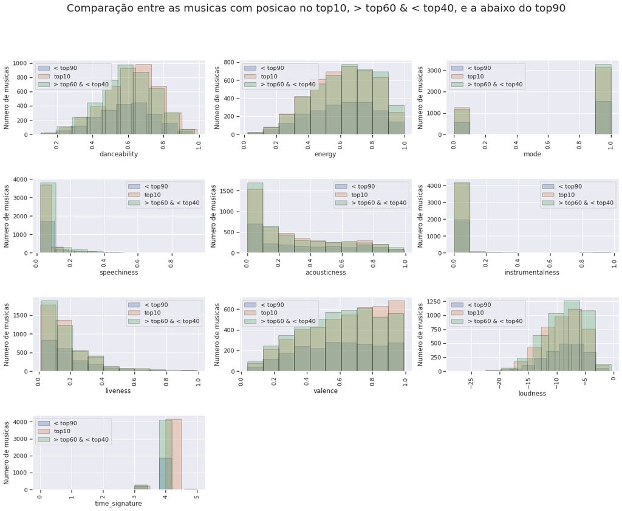

```python
fig = plt.figure(figsize=(20, 15))
fig.subplots_adjust(hspace=0.6, wspace=0.2)
fig.suptitle('Comparação entre as musicas com posicao no top10, > top60 & < top40, e a abaixo do top90', fontsize=20)

caracteristicas = ['danceability', 'energy', 'mode', 'speechiness', 'acousticness',
            'instrumentalness','liveness', 'valence','loudness','time_signature']

for index, feature in enumerate(caracteristicas):
    ax = fig.add_subplot(4,3,index+1)

    plt.hist(under_top90[feature], alpha=0.3, edgecolor='k', label='< top90')
    plt.hist(top10[feature], alpha=0.3, edgecolor='k', label='top10')
    plt.hist(avarage[feature], alpha=0.3, edgecolor='k', label='> top60 & < top40')

    despine()
    # Título do plot
    plt.title('')
    # Nome do eixo x
    plt.xlabel(feature)
    # Nome do eixo y
    plt.ylabel('Numero de musicas')
    # Rotaciona nomes no eixo x
    plt.xticks(rotation=90)
    plt.legend()
plt.show()
```

Pelos resultados, as caracteristicas nao aparentam influenciar na posicao da musica. Vamos selecionar uma caracteristica para aprofundar o resultado.

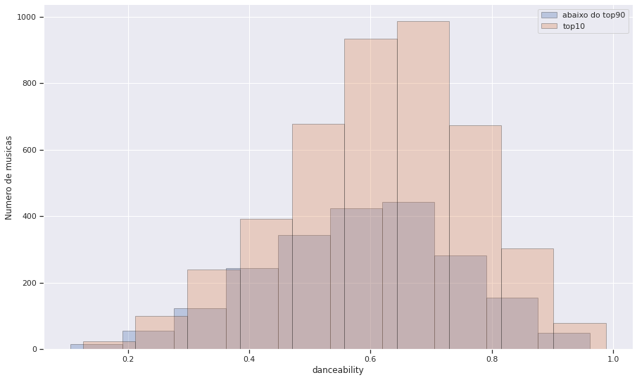

```python
plt.hist(under_top90['danceability'], alpha=0.3, edgecolor='k', label='abaixo do top90')
plt.hist(top10['danceability'], alpha=0.3, edgecolor='k', label='top10')
despine()
plt.xlabel('danceability')
plt.ylabel('Numero de musicas')
plt.legend()
plt.show()
```

```python
def bootstrap_mean(df, column, n=5000, size=None):
    '''
    Faz um boostrap da média. Gera amostras.

    Parâmetros
    ----------
    df: o dataframe
    column: a coluna que queremos focar
    n: número de amostras para o bootstrap
    size: tamanho de cada amostra, por padrão vira o tamanho do df.
    '''
    if size is None:
        size = len(df)
    values = np.zeros(n)
    for i in range(n):
        sample = df[column].sample(size, replace=True)
        values[i] = sample.mean()
    return values
```

```python
def ic_bootstrap(df, column, n=5000, size=None):
    '''
    Faz um IC boostrap da média. Gera um Intervalo.

    Parâmetros
    ----------
    df: o dataframe
    column: a coluna que queremos focar
    n: número de amostras para o bootstrap
    size: tamanho de cada amostra, por padrão vira o tamanho do df.
    '''

    values = bootstrap_mean(df, column, n, size)
    return (np.percentile(values, 2.5), np.percentile(values, 97.5))
```

```python
ic_bootstrap(top10, 'danceability')
```

```
(0.6124385242756285, 0.6212301454289129)
```

```python
ic_bootstrap(avarage, 'danceability')
```

```
(0.5892004713150517, 0.5981854192748449)
```

```python
ic_bootstrap(under_top90, 'danceability')
```

```
(0.5767036895130537, 0.5899340972222219)
```

```python
samples_top10 = bootstrap_mean(top10, 'danceability')
samples_avarage = bootstrap_mean(avarage, 'danceability')
samples_under_top90 = bootstrap_mean(under_top90, 'danceability')
to_plot = pd.DataFrame()
to_plot['top10_boot'] = samples_top10
to_plot['avarage_boot'] = samples_avarage
to_plot['under_top90_boot'] = samples_under_top90
```

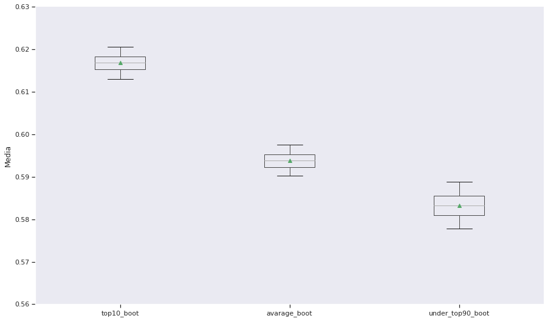

```python
to_plot.boxplot(grid=False, sym='', whis=[5, 95], showmeans=True)
plt.ylim(0.56, 0.63)
plt.ylabel('Media')
despine()
```

Pelo grafico, musicas com maior danceability, tendem a ter um posicao melhor no ranking top100 da billboard.

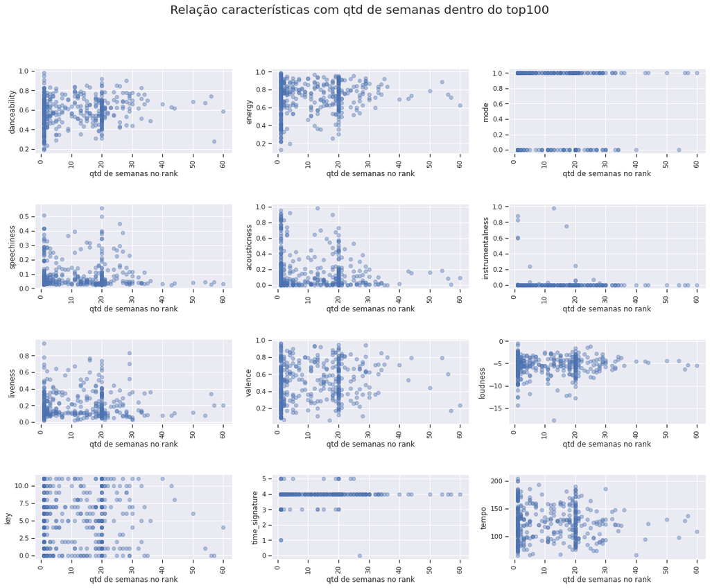

```python
number_position = hot.groupby('SongID').count()
features['posicao media'] = features.SongID.map(number_position['Week Position'].to_dict())

fig = plt.figure(figsize=(20, 15))
fig.subplots_adjust(hspace=0.6, wspace=0.2)
fig.suptitle('Relação características com qtd de semanas dentro do top100', fontsize=20)

caracteristicas = ['danceability', 'energy', 'mode', 'speechiness', 'acousticness',
            'instrumentalness','liveness', 'valence','loudness','key','time_signature','tempo']


for index, feature in enumerate(caracteristicas):
    ax = fig.add_subplot(4,3,index+1)

    plt.scatter(features[filtro2010]['posicao media'], features[filtro2010][feature], alpha = 0.4)

    despine()
    # Título do plot
    plt.title('')
    # Nome do eixo x
    plt.xlabel('qtd de semanas no rank')
    # Nome do eixo y
    plt.ylabel(feature)
    # Rotaciona nomes no eixo x
    plt.xscale('linear')
    plt.yscale('linear')
    plt.xticks(rotation=90)
#     plt.legend()
plt.show()
```

Pelos gráficos de dispersão, pode-se inferir que:

- músicas com danceability muito alta ou muito baixa tendem a não permanecer muito tempo no rank
- músicas com energy baixa tendem a não permanecer muito tempo no rank
- músicas com alta speechiness tendem a não permanecer muito tempo no rank
- músicas com alta acoustiness tendem a não permanecer muito tempo no rank

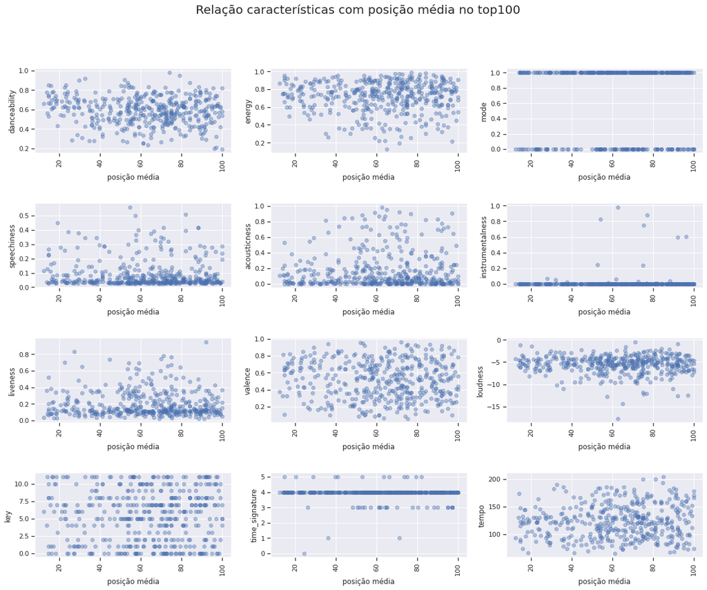

```python
avg_position = hot.groupby('SongID').mean()
features['posicao media'] = features.SongID.map(avg_position['Week Position'].to_dict())

fig = plt.figure(figsize=(20, 15))
fig.subplots_adjust(hspace=0.6, wspace=0.2)
fig.suptitle('Relação características com posição média no top100', fontsize=20)

for index, feature in enumerate(caracteristicas):
    ax = fig.add_subplot(4,3,index+1)

    plt.scatter(features[filtro2010]['posicao media'], features[filtro2010][feature], alpha = 0.4)

    despine()
    # Título do plot
    plt.title('')
    # Nome do eixo x
    plt.xlabel('posição média')
    # Nome do eixo y
    plt.ylabel(feature)
    # Rotaciona nomes no eixo x
    plt.xscale('linear')
    plt.yscale('linear')
    plt.xticks(rotation=90)
#     plt.legend()
plt.show()
```

Pelos gráficos de dispersão, não é possivel inferir alguma relação entre as características das músicas e sua posição média no rank da Billboard.

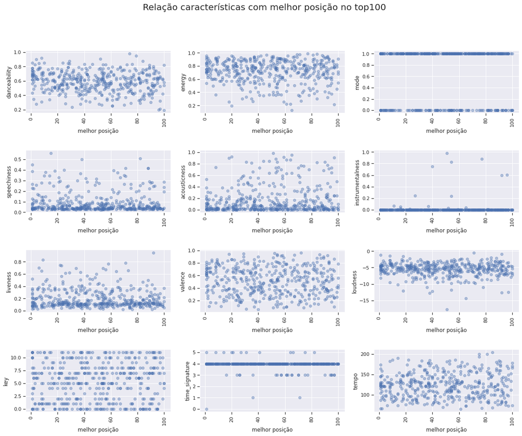

```python
best_position = hot.groupby('SongID').min()
features['posicao media'] = features.SongID.map(best_position['Week Position'].to_dict())

fig = plt.figure(figsize=(20, 15))
fig.subplots_adjust(hspace=0.6, wspace=0.2)
fig.suptitle('Relação características com melhor posição no top100', fontsize=20)

for index, feature in enumerate(caracteristicas):
    ax = fig.add_subplot(4,3,index+1)

    plt.scatter(features[filtro2010]['posicao media'], features[filtro2010][feature], alpha = 0.4)

    despine()
    # Título do plot
    plt.title('')
    # Nome do eixo x
    plt.xlabel('melhor posição')
    # Nome do eixo y
    plt.ylabel(feature)
    # Rotaciona nomes no eixo x
    plt.xscale('linear')
    plt.yscale('linear')
    plt.xticks(rotation=90)
#     plt.legend()
plt.show()
```

Pelos gráficos de dispersão, não é possivel inferir alguma relação entre as características das músicas e sua melhor posição no rank da Billboard.